# Python & Data Science Environment Setup

Today we will set up your data science workbench.

This includes:

- Installing the Python interpreter
- Learning essential terminal commands
- Setting up Git and GitHub Desktop
- Creating and using virtual environments
- Installing core data science libraries
- Launching and using JupyterLab

# What is the Python Interpreter?

A Python interpreter is the program that:

- Reads your Python code
- Executes it line by line
- Produces output

# Download Python

Get Python 3 from:

https://www.python.org/downloads/

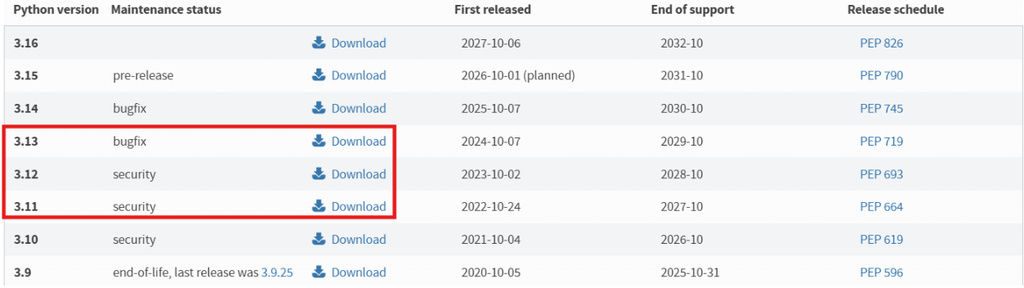

## Installation Notes

- Windows: Check “Add Python to PATH”
- Mac: Use the official installer

# What is a Terminal?

- Run programs
- Navigate folders
- Install packages
- Use Git

[figure not shown]

# Why Use a Terminal?

You will use it to:

### Manage Files

- Navigate folders
- Create directories

### Manage Software

- Install packages

### Run Tools

- Python
- JupyterLab

# Opening the Terminal

### Windows

1. Open the **Start Menu**
2. Type **PowerShell**
3. Click **Windows PowerShell**

### Mac

1. Press **⌘ + Space**
2. Type **Terminal**
3. Press **Enter**

# Verify Python Installation

### Run one of:

```
python --version
```

```
python3 --version
```

```
py --version  (Windows)
```

### Expected Output

[figure not shown]

# Basic Terminal Commands

Here are the most important commands you’ll use:

| Command | What It Does |
| --- | --- |
| `ls` | Lists files in the current directory |
| `cd folder_name` | Changes into a directory named `folder_name` |
| `cd ..` | Moves up one directory |
| `mkdir folder_name` | Creates a new directory named `folder_name` |
| `pwd` | Prints the current working directory |
| `clear` | Clears the console |
| `rm` | Removes a file from the directory |

# Example Use of Terminal

[figure not shown]

# What is Git?

Git is a version control system. It allows you to:

- Track changes in code
- Save snapshots of your work
- Revert to earlier versions
- Collaborate with others

## Creating a GitHub Account

GitHub is a website that stores Git repositories online.

In this course, we will use GitHub to:

- Store your projects in the cloud
- Submit assignments
- Track changes to your work
- Share code

# Go to GitHub

Visit https://github.com/.

Click **Sign up** in the top-right corner.

[figure not shown]

# GitHub Account Creation

You will be asked to provide:

- An email address
- A password
- A username

Choose a professional username (you may use GitHub in future internships or jobs).

After signing up, GitHub will send you a verification email. Open it and confirm your account.

# Log In

Once your account is verified, log in at:

https://github.com/login

You now have a GitHub account.

Next, we will connect GitHub to GitHub Desktop so you can easily clone repositories, commit changes, and push your work.

# Forking a Repository

To submit your own work, you need your *own copy* of the course repository.

We do this using something called a **fork**.

[figure not shown]

# What is a Fork?

A **fork** creates a copy of a repository under *your own GitHub account*.

After you fork:

- You can make changes freely
- You can push updates
- You control your version
- The original course repository remains unchanged

# Why Fork?

If you clone the instructor's repository directly, you **cannot push changes** to it.

By forking:

- You create your own version
- You push to your version
- You submit the link to your repository

# GitHub Dekstop

We will use GitHub Desktop for simplicity. Download it here:

https://desktop.github.com/

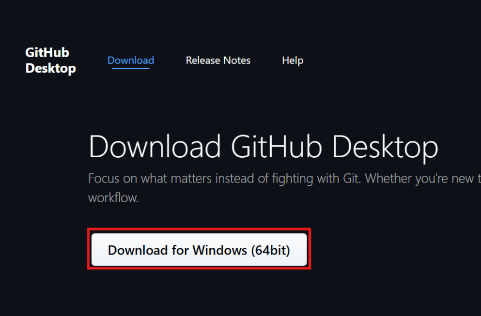

# Cloning a Repository

Cloning means downloading a repository from GitHub to your computer. After copying and pasting the the link to the repository, open up GitHub Desktop, click on File, and choose the clone repository option.

[figure not shown]

# Getting Repo URL

Click on the code button and then copy the URL for the repository.

[figure not shown]

# Cloning in GitHub Desktop

Paste the URL for the repository into the box provided in GitHub Desktop. Select a local folder and click clone.

[figure not shown]

# Cloning to Local Folder

You can now navigate to this repository in the terminal on your machine.

[figure not shown]

# Virtual Environments

A virtual environment is an isolated Python environment. These are useful because different projects may require:

- Different package versions
- Different dependencies

Virtual environments prevent conflicts between projects.

# Creating a Virtual Environment

A virtual environment keeps your project’s Python packages isolated from other projects. Open your terminal and move into your project directory:

```
cd my_project
```

This is the folder where we want to create the virtual environment.

# Create the Virtual Environment

Run:

```
python -m venv venv
```

This creates a new folder named `venv` inside your project.

[figure not shown]

# Activate the Virtual Environment

### On Mac / Linux

```
source venv/bin/activate
```

### On Windows (PowerShell)

```
venv\Scripts\activate
```

[figure not shown]

## Confirm It Worked

You should now see `(venv)` at the beginning of your terminal line, for example:

```
(venv) user@computer my_project %
```

This means your virtual environment is active. Don't do this right now, but when you're finished working, in the terminal run:

```
deactivate
```

# Install Data Science Libraries

Once your virtual environment is activated, install the required libraries by running:

```
pip install numpy pandas matplotlib seaborn scikit-learn jupyterlab
```

This command installs most required packages for the course in one step.

# Library Documentation

| Library | Purpose | Documentation |
| --- | --- | --- |
| **NumPy** | Numerical computing and arrays | https://numpy.org/doc/ |
| **Pandas** | Data manipulation and DataFrames | https://pandas.pydata.org/docs/ |
| **Matplotlib** | Core plotting library | https://matplotlib.org/stable/contents.html |
| **Seaborn** | Statistical visualization | https://seaborn.pydata.org/ |
| **Scikit-Learn** | Machine learning tools | https://scikit-learn.org/stable/ |
| **JupyterLab** | Interactive notebook environment | https://jupyterlab.readthedocs.io/ |

# Running JupyterLab

Now we are ready to run JupyterLab. In the terminal, run:

```
jupyter lab
```

This will start a local server on your machine where JupyterLab is running.

# JupyterLab Interface Overview

## File Browser and Launcher (Left Panel)

Browse and open files. Create notebooks, consoles, or terminals.

[figure not shown]

## Notebook Area

Write and execute code.

[figure not shown]

## Terminal (Inside JupyterLab)

You can open a terminal inside JupyterLab if needed.

[figure not shown]